# Building a Spatially Varying Coefficient Model in Continuous Space Using R-INLA

Timothy D. Meehan and Elias T. Krainski

2022-08-11

## Introduction

Spatially varying coefficient models (SVCs, Gelfand et al. 2003) are often used to model data when relationships between dependent and independent variables are not uniform across space, a common situation when exploring phenomena across large spatial extents (Finley 2011). Meehan et al. (2019) described an SVC model to evaluate continent-scaled variation in bird abundance trends. The SVC model used in that analysis employed discrete aerial units (100 km grid cells), with spatial structure described by neighborhood matrices and spatial relationships described by an intrinsic conditional autoregressive model (Besag 1974). The online supplement for the paper included code for building the model using the `R-INLA` package (Rue et al. 2009) for the `R` statistical programming language (R Core Team 2021). Both the manuscript and code can be accessed at https://github.com/tmeeha/inlaSVCBC.

In this vignette, we will describe how to build an SVC model similar to that described in Meehan et al. (2019), but within a continuous-space framework. This model will be computed using the stochastic partial differential equation (SPDE) approach of Lindgren et al. (2011, 2022), implemented in the `R-INLA` package for `R`. The SPDE approach employs a computationally efficient approximation of a Gaussian random field with parameters directly comparable to those of a Matérn covariance function. The benefits of a continuous-space versus a discrete-space SVC include the potential for finer resolution estimation and prediction, a better understanding of the range of spatial correlation, and a reduction in boundary effects associated with discreet-space analyses.

We build the model using a subset of the data described in Meehan et al. (2019). Specifically, we use counts of American Robin (*Turdus migratorius*) from south central North America collected between 1987 and 2016 during the Audubon Christmas Bird Count (CBC). The overall goal of the analysis is to produce spatially explicit estimates of annual relative abundance as well as long-term relative abundance trends for robins that account for spatial and temporal variation in count effort.

## Model

The model used to analyze these data assumes that counts come from a negative binomial distribution with an expected count and dispersion parameter. The expected count has a linear predictor:

$$log(\lambda_{st}) = \kappa_{s} +
\alpha_s + \epsilon_{s}(log[Effort_{st}]) +
\tau_{s}(Year_{st})$$

where the natural log of expected count, $log(\lambda_{st})$, at site $s$ during year $t$, is modeled with a zero-centered, normally distributed intercept per site, $\kappa_s$, a spatially varying intercept, $\alpha_s$, a spatially varying effect of the log of count effort in hours, $\epsilon_s$, and a spatially varying linear effect of year, $\tau_s$. The spatially structured effects are modeled as Gaussian random fields with Matérn covariance functions with range and variance parameters.

Model parameters $\kappa_s$, $\alpha_s$, $\epsilon_s$ and $\tau_s$ are analogous to those in Meehan et al. (2019). For example, $\kappa_s$ is included to account for site-level differences in counts, possibly due to habitat availability or observer experience. $\alpha_s$ can be interpreted as an effort-corrected abundance index at year zero. $\epsilon_s$ is the exponent for a power-law effort-correction function. And $\tau_s$ is the long-term temporal trend at a given site.

## Environment

To get started with data analysis, we set up the environment, which involves setting working directories, loading some packages, and setting some options.

```r
# working directory
setwd(getwd())

# libraries
library(maps); library(ggplot2); library(sf); library(raster);
library(tidyr); library(scales); library(inlabru); library(INLA); library(dplyr)

# set option
select <- dplyr::select
options(scipen=99999)
options(max.print=99999)
options(stringsAsFactors=F)
```

Next we define a coordinate reference system (CRS) for spatial analysis and create a base map for later use. The CRS uses the USA Contiguous Albers Equal-Area Conic projection, and is identified by the EPSG code 6703. We modify the CRS slightly to have units of kilometers, so that distances between widespread count sites are not especially large numbers (Krainski et al. 2018).

```r
# define a crs
epsg6703km <- paste("+proj=aea +lat_0=23 +lon_0=-96 +lat_1=29.5",
                    "+lat_2=45.5 +x_0=0 +y_0=0 +datum=NAD83",
                    "+units=km +no_defs")

# make a base map
states <- st_as_sf(maps::map("state", plot = FALSE, fill = TRUE)) %>%
  filter(ID %in% c("texas", "oklahoma", "kansas", "missouri",
                   "arkansas", "louisiana")) %>%
  st_transform(epsg6703km)
```

## Import data

```r
# get data
download_dat <- read.csv(paste0("https://raw.github.com/tmeeha/inlaSVCBC",
                  "/master/code/modeling_data.csv"))

# select subset
count_dat <- download_dat %>%
  select(circle, bcr, state, year, std_yr, count, log_hrs,
         lon, lat, obs) %>%
  mutate(year=year+1899) %>%
  filter(state %in% c("TEXAS", "OKLAHOMA", "KANSAS", "MISSOURI",
                      "ARKANSAS", "LOUISIANA"),
         year>=1987) %>%
  mutate(site_idx=as.numeric(factor(paste(circle, lon, lat)))) %>%
  group_by(site_idx) %>% mutate(n_years=n()) %>%
  filter(n_years>=20) %>% ungroup() %>%
  mutate(std_yr=year-max(year), obs=1:nrow(.),
         site_idx=as.numeric(factor(paste(circle, lon, lat))),
         year_idx=as.numeric(factor(year)),
         site_year_idx=as.numeric(factor(paste(circle, lon, lat, year)))) %>%
  st_as_sf(coords=c("lon", "lat"), crs=4326, remove=F) %>%
  st_transform(epsg6703km) %>%
  mutate(lon=st_coordinates(.)[,1], lat=st_coordinates(.)[,2]) %>%
  arrange(circle, year)
```

A rough view of changes in robin relative abundance that does not account for variation in count effort can be seen by plotting raw counts per site and year.

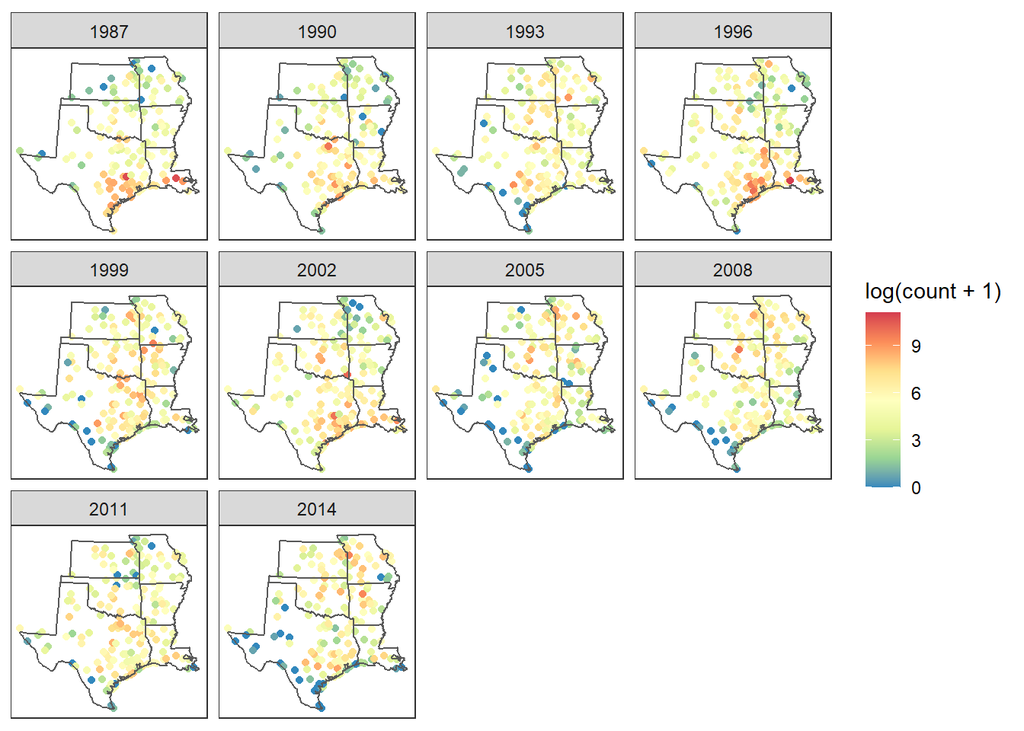

```r
# map it
ggplot() +
  geom_sf(data=count_dat %>% filter(year_idx %in% seq(1, 30, 3)),
          aes(col=log(count+1))) +
  geom_sf(data=states, fill=NA) + coord_sf(datum = NA) +
  facet_wrap(~year) + scale_color_distiller(palette="Spectral") + theme_bw()
```

## Make spatial data

Next we use the count data to make a map of distinct count sites and save the coordinates of the sites, unique and across all years, for later spatial modeling.

```r
# make a set of distinct study sites for mapping
site_map <- count_dat %>% select(circle, lon, lat) %>%
  distinct() %>% select(circle, lon, lat)

# save coordinates as matrices for later
unique_coords <- count_dat %>% select(circle, lon, lat) %>%
  distinct() %>% select(lon, lat) %>%  st_drop_geometry %>% as.matrix()
all_coords <- as.matrix(st_coordinates(count_dat))
```

## SPDE components

Computing a continuous-space model with `R-INLA` using the SPDE approach requires construction of four distinct sets of data and model objects (Blangiardo and Cameletti 2015, Krainski et al. 2018). First, we create a **modeling mesh**, which is considered for a representation of the continuous spatial surface based on triangulation of the modeled region. Here, the same mesh will get reused for each of the spatial terms in the model. Second, we construct an **SPDE model object** that specifies properties of the spatial model. Again, we will use the same SPDE object for each of the spatial terms in the model. Third, we create **named index sets** that identify data locations and mesh nodes for use in model construction, computation, and output extraction. Note that a separate set of indices needs to be constructed for each spatial term in the model. Fourth, we construct **projector matrices** or **A matrices** that create formulaic mappings between the observed data locations and the mesh nodes. Again, note that a separate set of projector matrices needs to be constructed for each spatial term in the model. The four corresponding INLA functions for these steps are: `inla.mesh.2D()`, `inla.spde2.pcmatern()`, `inla.spde.make.index()`, and `inla.spde.make.A()`.

## Modeling mesh

There are several things to consider when constructing a mesh (Lindgren and Rue 2015, Blangiardo and Cameletti 2015, Krainski et al. 2018, Bakka et al. 2018). In constructing one, we balance a trade-off between capturing fine-scaled features of the Gaussian random field and computing times. Here, we create a non-convex hull around the count sites, and then build a triangular mesh by specifying minimum and maximum edge lengths within and slightly outside the hull.

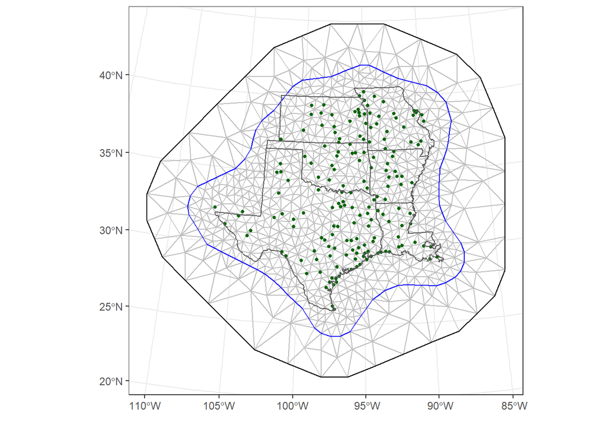

```r
# make a hull and mesh for spatial model
hull <- inla.nonconvex.hull(points=unique_coords, 200, 350)
mesh <- inla.mesh.2d(boundary=hull, max.edge=c(100, 600), # km inside and outside
                       cutoff=50, offset=c(100, 300)) # cutoff is min edge

# plot it
ggplot() + gg(data=mesh) +
  geom_sf(data=site_map, col="darkgreen", size=1) +
  geom_sf(data=states, fill=NA) + theme_bw() +
  labs(x="", y="")
```

## SPDE model object

Next we create an SPDE object to define the model smoothness, to provide prior distributions for the variance and range parameters and the mesh. Here we assume a Gaussian random field characterized with a Matérn covariance function with penalized complexity priors (Simpson et al. 2017) for the practical range (distance where spatial correlation approaches 0.1) and variation explained by the function (Fuglstad et al. 2019). The prior for the spatial range is set such that the probability of a range exceeding 500 km is 0.5. The prior for the variance explained by the spatial effect is set such that the probability of a standard deviation exceeding 1 is 0.5 (Krainski et al. 2018). If one wants to constrain this kind of spatial effect to sum to zero, `constr=T` should be added at this stage.

```r
# make spde
spde <- inla.spde2.pcmatern(mesh=mesh, prior.rang=c(500, 0.5), prior.sigma=c(1, 0.5))
```

## Index sets

Next we create index sets for the spatial terms in the model. Note that the `tag` names applied to the index sets in this step will be used in the model formula statement below. The index vectors for the spatial terms are essentially vectors of integers going from 1 to the number of nodes on the mesh.

```r
# make index sets
alpha_idx <- inla.spde.make.index(name='alpha', n.spde=mesh$n)
eps_idx <- inla.spde.make.index(name='eps', n.spde=mesh$n)
tau_idx <- inla.spde.make.index(name='tau', n.spde=mesh$n)
```

## Projector matrices

```r
# make projector matrices
A_alpha <- inla.spde.make.A(mesh=mesh, loc=all_coords)
A_eps <- inla.spde.make.A(mesh=mesh, loc=all_coords,
                          weights=count_dat$log_hrs) # note weights argument
A_tau <- inla.spde.make.A(mesh=mesh, loc=all_coords,
                          weights=count_dat$std_yr) # note weights argument
```

## Data stack for model fitting

With the SPDE method, there are several data structures that need to be bundled and used for analysis of the spatial model. There is the observed response at the count sites, the covariate values at the count sites, and the indices and mapping of those data to the modeling mesh. All of this information gets bundled into a data stack for model analysis using the `inla.stack()` function. This function is a very flexible and can be difficult to understand at first. See Blandgiardo and Cameletti (2015) and Gomez-Rubio (2020) for practical information on how to use it.

The first argument to the function, shown below, is the `tag` name for the stack. In this case we are including observed data for model estimation, so we name the stack ‘obs’. The next argument, `data`, specifies the response variable. Here we have a single response variable called ‘count’. We tell the stacking function that observed counts reside in the ‘count_dat’ data set. The next argument, `effects`, is used to specify the model predictors. These are defined using the observed data for non-spatial predictors, and using the named index sets for the spatial predictors. The last argument, `A`, asks for a list of projector matrices or A matrices for the predictor variables. We did not need to make a projector for $\kappa_s$, because it is not defined as a spatial parameter. Nevertheless, we add a value of 1 because it is the value that will be multiplied by the effect during model computations and serves as a way for the stacking function to match the number of A matrices with the number of effects – if there are 4 effects, then there must be four entries for `A`. Note that if there were more than one non-spatial predictor in the model, whether a grouped random intercept or a global fixed effect, then each one would be given its own value of 1 during this step. And note that the order of the A matrices must match the order of the effects.

```r
# stack observed data
stack_fit <- inla.stack(
  tag = 'obs',
  data = list(count = as.vector(count_dat$count)), # response from data frame
  effects = list(data.frame(intercept=1,
                            kappa = count_dat$site_idx), # predictors from data frame
                 alpha = alpha_idx,          # or index sets if spatial
                 eps = eps_idx,
                 tau = tau_idx),
  A = list(1,        # a value of 1 is given for non-spatial terms
           A_alpha,
           A_eps,
           A_tau)
)
```

It is possible to construct additional data stacks for creating predictions, and then stack the estimation and predictions stacks together for analysis. We do not do that in this example. Information on adding prediction stacks in an SPDE context can be found in Krainski et al. (2018, chapter 2) and Moraga (2019, chapter 10).

## Model formula

```r
# iid prior
pc_prec <- list(prior = 'pcprec', param = c(1, 0.1))
```

The model described above is translated to `R-INLA` modeling syntax as:

```r
# formula
svc_form <- count ~ -1 +
  f(kappa, model ="iid", constr = T, hyper = list(prec = pc_prec)) +
  f(alpha, model = spde) +
  f(eps, model = spde) +
  f(tau, model = spde)
```

Here, we define the response as `count`, remove the automatic global intercept with a `-1`, and then specify the other terms in the model with `f()` statements. The first `f()` statement defines $\kappa_s$, the site effect, as a normally distributed (`model="iid"`), zero-centered (`constr=T`), deviation from $\alpha_s$. The name ‘kappa’ given in the `f()` argument is associated with the effect ‘kappa’ defined in the estimation stack. The second `f()` statement defines $\alpha_s$ as a spatially varying intercept with spatial structure described by the SPDE object called ‘spde’. Remember that if one wants to constrain this kind of spatial effect to sum to zero, `constr=T` should be added in the SPDE model definition rather than in the `f()` arguments. The third `f()` statement defines $\epsilon_s$ as an SVC for the effect of count effort, with spatial structure also described by the SPDE object. The weights for this spatially structured random slope were specified during construction of the projector A matrix, `A_eps`. The fourth `f()` statement defines $\tau_s$ as an SVC for the year effect, with spatial structure described in the SPDE object. The weights for this spatially structured random slope were specified during construction of the projector A matrix, `A_tau`. Again, note that the current use of the term ‘weights’ is to define covariate values, as opposed to importance values.

## Run model

```r
# run model, takes about 5 minutes
inla.setOption(inla.mode="experimental")
res <- inla(svc_form,
            family="nbinomial",
            data=inla.stack.data(stack_fit), # stack the stack
            control.predictor=list(A=inla.stack.A(stack_fit),
                                   compute=F), # must define A
            control.compute=list(waic=T, cpo=T, config=T),
            control.inla=list(strategy='adaptive', int.strategy='eb'),
            verbose=F)
```

## Model summaries

Once computation is complete, we look at the initial results to see how things went. First we check the posterior means for the hyperparameters of the model, mainly the variance components and the spatial ranges of the spatially structured parameters.

```r
# view results
res$summary.hyperpar[-1, c(1,2)]
```

```
##                              mean            sd
## Precision for kappa    2.17856256    0.40682005
## Range for alpha     1084.59272444  355.58983828
## Stdev for alpha        2.21299708    0.49434092
## Range for eps       9420.65637870 6983.03650641
## Stdev for eps          0.27442211    0.15098659
## Range for tau       1010.31263830  426.39897437
## Stdev for tau          0.07670835    0.02232708
```

```r
summary(exp(res$summary.random$alp$mean)) # alpha
```

```
##     Min.  1st Qu.   Median     Mean  3rd Qu.     Max.
##  0.03535  1.18057  3.70320  7.36555  9.16695 52.52619
```

The summary for $\epsilon_s$ shows variation in the exponent for the effort correction function across space.

```r
summary(res$summary.random$eps$mean) # epsilon
```

```
##    Min. 1st Qu.  Median    Mean 3rd Qu.    Max.
##  0.8482  0.9050  0.9575  0.9488  0.9941  1.0241
```

```r
summary((exp(res$summary.random$tau$mean)-1)*100) # tau
```

```
##    Min. 1st Qu.  Median    Mean 3rd Qu.    Max.
## -13.664  -5.645  -1.898  -1.345   2.881  12.218
```

## SVC maps

Next we create maps of $\alpha_s$, $\epsilon_s$, and $\tau_s$ to inspect the spatial structure of these parameter estimates. We start by creating a 25-km mapping grid, and then projecting this mapping grid to the modeling mesh.

```r
# get lon and lat limits
xlim <- range(hull$loc[, 1])
ylim <- range(hull$loc[, 2])
grd_dims <- round(c(x=diff(range(xlim)), y=diff(range(ylim)))/25)

# make mesh projector to get model summaries from the mesh to the mapping grid
mesh_proj <- inla.mesh.projector(
    mesh, xlim=xlim, ylim=ylim, dims=grd_dims)
```

Then we populate the mapping grids with parameter estimates (posterior mean and SD), turn them into a raster stack, and mask the raster stack to the study area.

```r
# pull data
alph <- exp(res$summary.random$alp[, c(2:3)])
epsi <- res$summary.random$eps[, c(2:3)]
taus <- (exp(res$summary.random$tau[, c(2:3)]) - 1) * 100

# loop to get estimates on a mapping grid
pred_grids <- lapply(list(alpha=alph, epsilon=epsi, tau=taus),
                 function(x) as.matrix(inla.mesh.project(mesh_proj, x)))

# make a raster stack with the posterior mean and SD
out_stk <- stack()
for(j in 1:3){
  mean_j <- cbind(expand.grid(X=mesh_proj$x, Y=mesh_proj$y),
            Z=c(matrix(pred_grids[[j]][,1], grd_dims[1])))
  mean_j <- rasterFromXYZ(mean_j, crs=epsg6703km)
  sd_j <- cbind(expand.grid(X=mesh_proj$x, Y=mesh_proj$y),
            Z=c(matrix(pred_grids[[j]][,2], grd_dims[1])))
  sd_j <- rasterFromXYZ(sd_j, crs=epsg6703km)
  out_j <- stack(mean_j, sd_j)
  out_stk <- addLayer(out_stk, out_j)
}
names(out_stk) <- c("alpha_mean", "alpha_sd", "epsilon_mean",
                    "epsilon_sd", "tau_mean", "tau_sd")
out_stk <- mask(out_stk, as(states, "Spatial"))
```

Finally, we plot the SVC for $\tau_s$ with the following code.

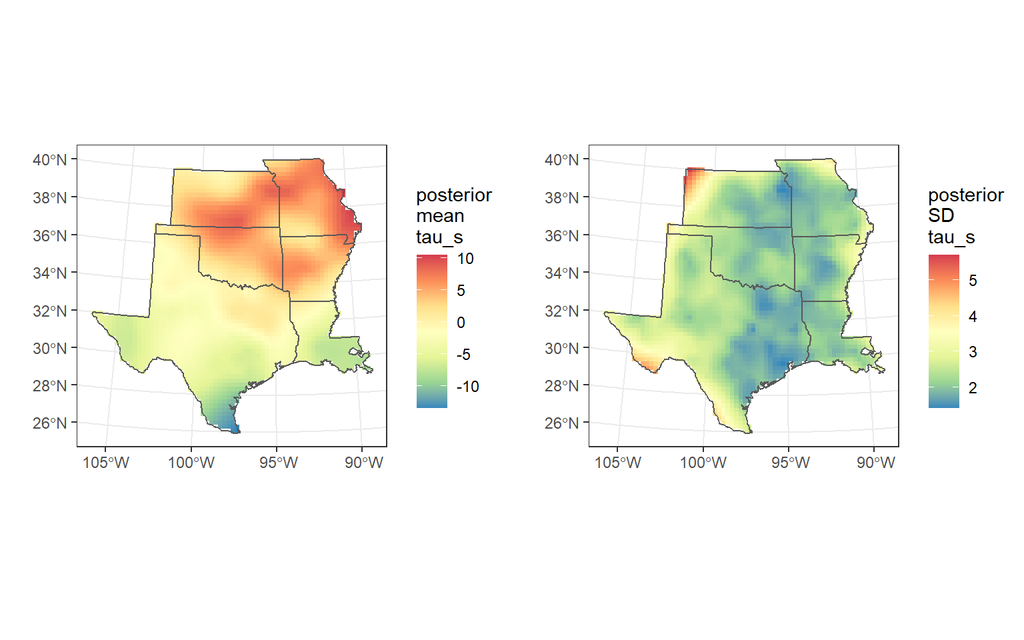

```r
# sites
ps <- ggplot(states) + geom_sf() + coord_sf(datum = NA) +
  geom_sf(data=site_map, size=0.5) +
  labs(x="", y="") +
  theme_bw() + geom_sf(fill=NA)

# tau_s
tau_spdf <- as(out_stk[[5]], "SpatialPixelsDataFrame")
tau_df <- as.data.frame(tau_spdf)
colnames(tau_df) <- c("value", "x", "y")
pt <- ggplot(states) + geom_sf(fill=NA) + coord_sf(datum = NA) +
  geom_tile(data=tau_df, aes(x=x, y=y, fill=value)) +
  labs(x="", y="") +
  scale_fill_distiller("posterior\nmean\ntau_s", palette="Spectral") +
  theme_bw() + geom_sf(fill=NA)

# tau_s sd
tau_spdf <- as(out_stk[[6]], "SpatialPixelsDataFrame")
tau_df <- as.data.frame(tau_spdf)
colnames(tau_df) <- c("value", "x", "y")
psd <- ggplot(states) + geom_sf(fill=NA) + coord_sf(datum = NA) +
  geom_tile(data=tau_df, aes(x=x, y=y, fill=value)) +
  labs(x="", y="") +
  scale_fill_distiller("posterior\nSD\ntau_s", palette="Spectral") +
  theme_bw() + geom_sf(fill=NA)

# plot together
multiplot(pt, psd, cols=2)
```

## More information

More information on building spatial models using the SPDE approach in R-INLA can be found in Lindgren and Rue (2015), Blangiardo and Camaletti (2015), Bakka et al. (2018), Krainski et al. (2018), and Moraga (2019).

## Citations

Bakka, H., Rue, H., Fuglstad, G.A., Riebler, A., Bolin, D., Illian, J., Krainski, E., Simpson, D. and Lindgren, F., 2018. Spatial modeling with R‐INLA: A review. Wiley Interdisciplinary Reviews: Computational Statistics, 10(6), p.e1443.

Besag, J., 1974. Spatial interaction and the statistical analysis of lattice systems. Journal of the Royal Statistical Society: Series B (Methodological), 36(2), pp.192-225.

Blangiardo, M., Cameletti, M., Baio, G. and Rue, H., 2013. Spatial and spatio-temporal models with R-INLA. Spatial and spatio-temporal epidemiology, 4, pp.33-49.

Finley, A.O., 2011. Comparing spatially‐varying coefficients models for analysis of ecological data with non‐stationary and anisotropic residual dependence. Methods in Ecology and Evolution, 2(2), pp.143-154.

Fuglstad, G.A., Simpson, D., Lindgren, F. and Rue, H., 2019. Constructing priors that penalize the complexity of Gaussian random fields. Journal of the American Statistical Association, 114(525), pp.445-452.

Gelfand, A.E., Kim, H.J., Sirmans, C.F. and Banerjee, S., 2003. Spatial modeling with spatially varying coefficient processes. Journal of the American Statistical Association, 98(462), pp.387-396.

Gómez-Rubio, V., 2020. Bayesian inference with INLA. CRC Press.

Krainski, E., Gómez-Rubio, V., Bakka, H., Lenzi, A., Castro-Camilo, D., Simpson, D., Lindgren, F. and Rue, H., 2018. Advanced spatial modeling with stochastic partial differential equations using R and INLA. Chapman and Hall/CRC.

Lindgren, F., Rue, H. and Lindström, J., 2011. An explicit link between Gaussian fields and Gaussian Markov random fields: the stochastic partial differential equation approach. Journal of the Royal Statistical Society: Series B (Statistical Methodology), 73(4), pp.423-498.

Lindgren, F. and Rue, H., 2015. Bayesian spatial modelling with R-INLA. Journal of statistical software, 63, pp.1-25.

Lindgren, F., Bolin, D. and Rue, H., 2022. The SPDE approach for Gaussian and non-Gaussian fields: 10 years and still running. Spatial Statistics, p.100599.

Link, W.A., Sauer, J.R. and Niven, D.K., 2006. A hierarchical model for regional analysis of population change using Christmas Bird Count data, with application to the American Black Duck. The Condor, 108(1), pp.13-24.

Meehan, T.D., Michel, N.L. and Rue, H., 2019. Spatial modeling of Audubon Christmas Bird Counts reveals fine‐scale patterns and drivers of relative abundance trends. Ecosphere, 10(4), p.e02707.

Moraga, P., 2019. Geospatial health data: Modeling and visualization with R-INLA and shiny. CRC Press.

R Core Team (2021). R: A language and environment for statistical computing. R Foundation for Statistical Computing, Vienna, Austria. URL https://www.R-project.org/.

Rue, H., Martino, S. and Chopin, N., 2009. Approximate Bayesian inference for latent Gaussian models by using integrated nested Laplace approximations. Journal of the royal statistical society: Series b (statistical methodology), 71(2), pp.319-392.

Simpson, D., Rue, H., Riebler, A., Martins, T.G. and Sørbye, S.H., 2017. Penalising model component complexity: A principled, practical approach to constructing priors. Statistical science, 32(1), pp.1-28.

Soykan, C.U., Sauer, J., Schuetz, J.G., LeBaron, G.S., Dale, K. and Langham, G.M., 2016. Population trends for North American winter birds based on hierarchical models. Ecosphere, 7(5), p.e01351.

Van Niekerk, J. and Rue, H., 2021. Correcting the Laplace Method with Variational Bayes. Journal of Machine Learning Research, Under review.

Van Niekerk, J. and Krainski, E. T. and Rustand, D. and Rue, H., 2022. A new avenue for Bayesian inference with INLA. Submitted.